# —

## Anomaly Detection

The objective of this analysis is to implement an anomaly detection algorithm to detect anomalous behavior in server computers. The features measure the through- put (mb/s), latency (ms) andother parameters of response of each server. While servers were operating, 1100 examples of how they were behaving were collected. Initial 1000 observations are all normal responses and there are 10 anomalies in final 100 observations which are used for validation of the model. Gaussian model will be used to detect anomalous observations in the dataset.

## Model:

[output not shown]

## Exploratory analysis of the features:

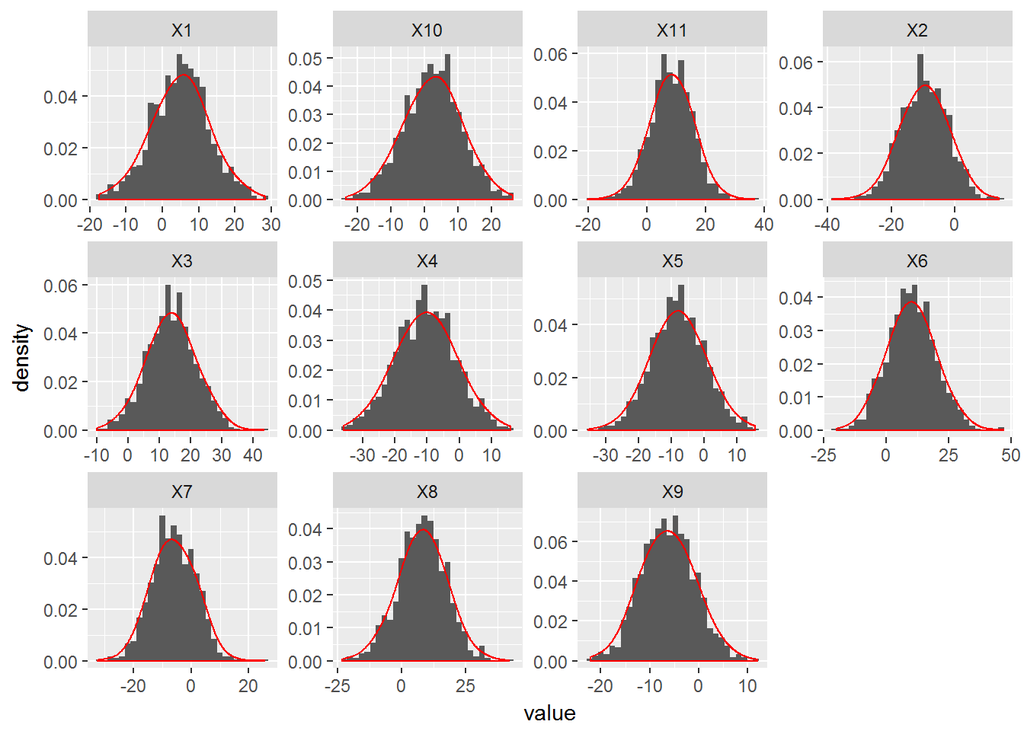

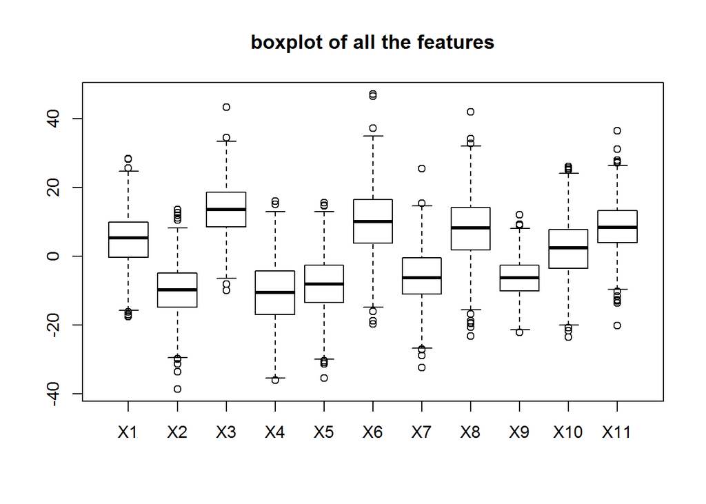

### Train data:

All the eleven features of the dataset look like they follow normal distribution from the above plots. Let’s have a look at their QQPlots and resuts of tests of normality:

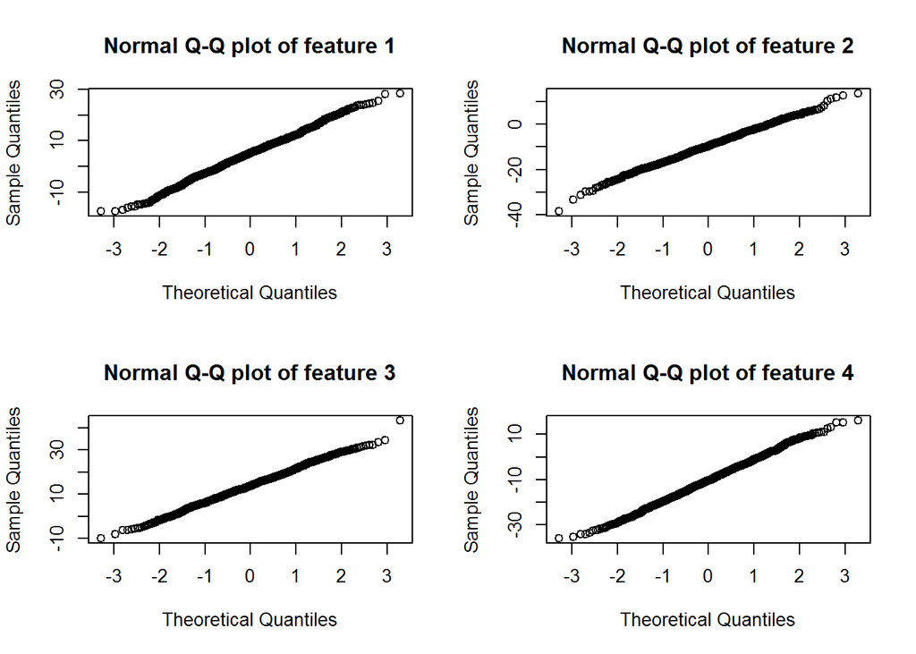

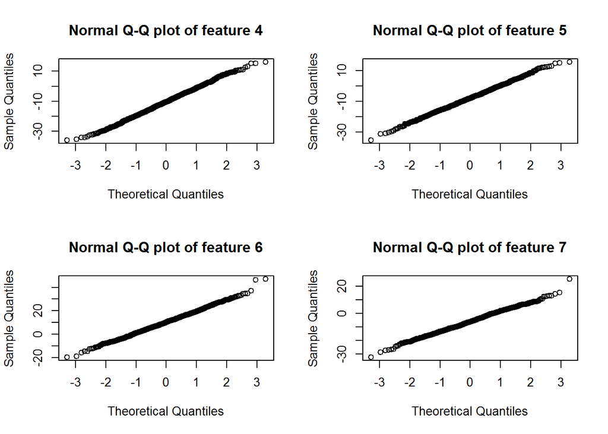

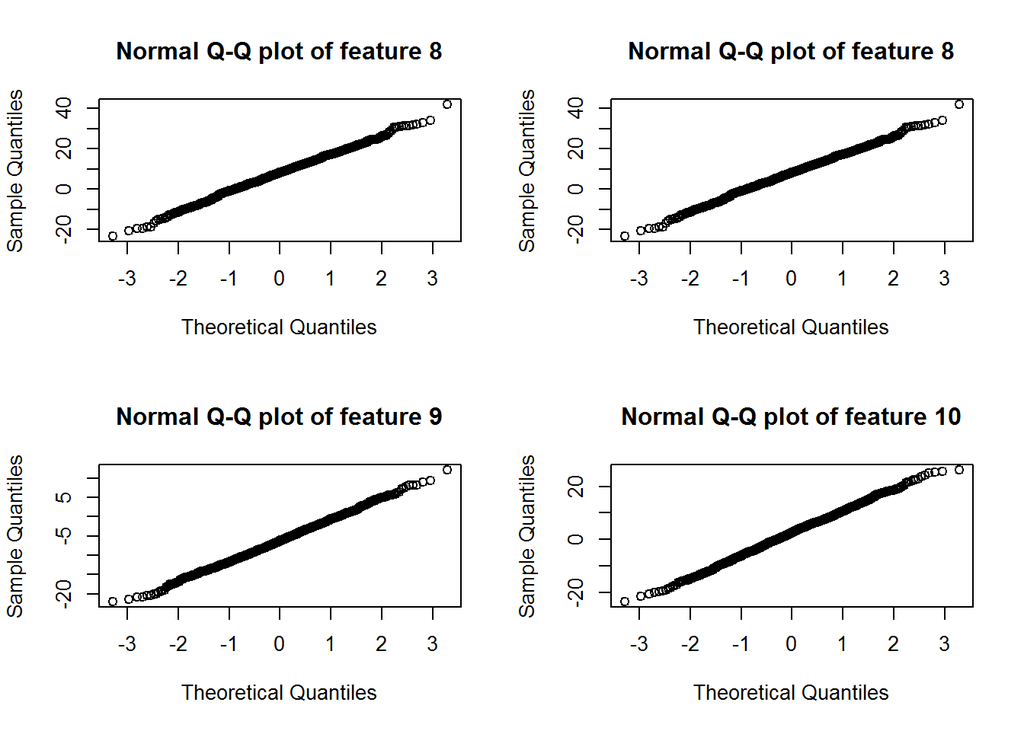

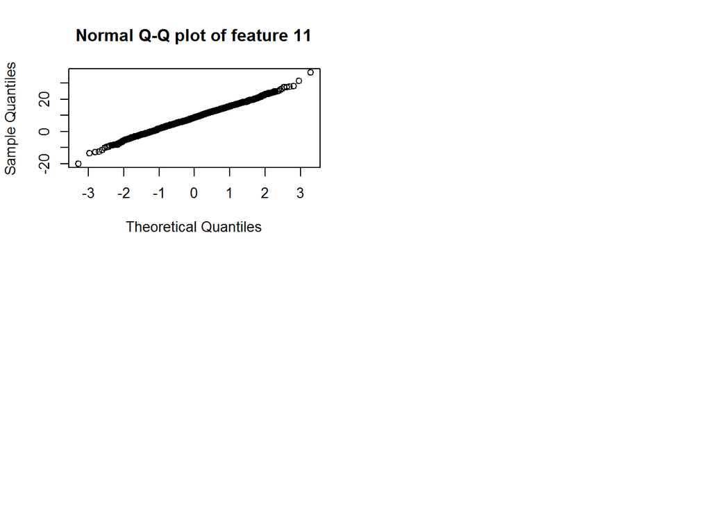

p-values of the Shapiro and Anderson_darling tests are as follows:

```
##                X1        X2        X3        X4        X5        X6
## shapiro 0.1609494 0.6697672 0.6582598 0.5722965 0.9618786 0.4980186
## adtest  0.1207252 0.8379918 0.7837818 0.9635222 0.9756475 0.9267057
##                X7        X8        X9       X10       X11
## shapiro 0.1774801 0.3881551 0.8004087 0.6326609 0.4665709
## adtest  0.1469380 0.2843801 0.7784174 0.5199585 0.6737168
```

Under the modeled probability distribution function, joint probabilities for the observations of validation set are calculated and the threshold value probability to categorize anomalies, is chosen as the value which maximizes the performance criterion (F1- score) of this model on validation set. In this analysis, joint probability distribution has been modeled without any assumption of independence between the features ( although it would have been very costly in terms of computing if we had a very large data set of aroung millions of rows). In case of large data sets, joint distribution can be modeled under assumtion of independence of features.

## Choosing threshold:

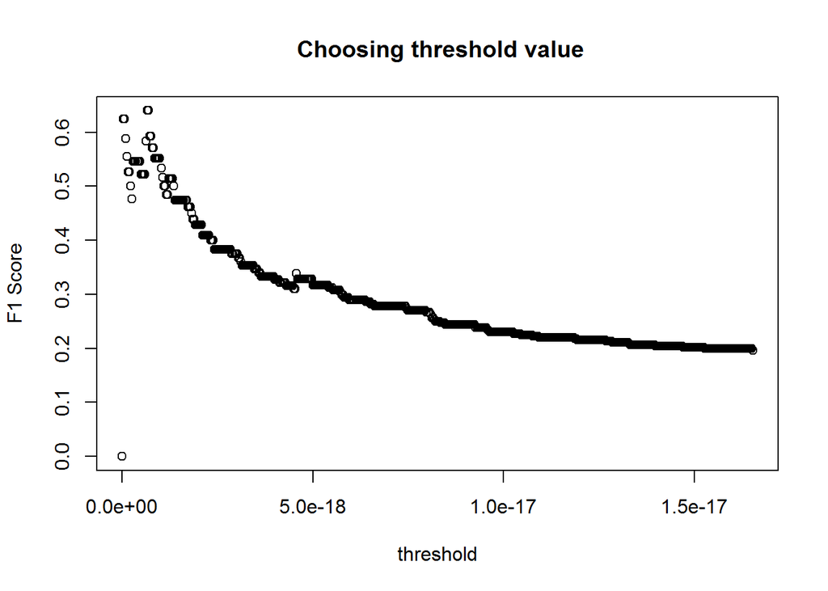

## Results:

#### Misclassifcation table for this threshold for validation set:

83, 7, 2, 8

#### F1 - score for this threshold:

0.64

## Conclusion:

This unsupervised machine learning technique is particularly useful, when there are very few anomalies in our data (such as 10 anomalies out of 1000 or 10000 observations), in which case applying other suervised machine learning techniques becomes difficult.

## Disadvantages:

```
Major disadvantage of this model is it cant properly differentiate between rarely occuring normal cases and anomalies.
```

Reference: “Machine Learning Coursera Specialization by Mr. Andrew N G”

```
                                  ***THE END***
```